# Confirmatory Factor Analysis (CFA)

Author

Riccardo Volpato

```r
library(tidyverse)
library(semTools)
library(knitr)
```

# Data Processing

```r
options(readr.show_col_types = FALSE)
file_path <- "data/shared/TPSai+–+Prolific_CFA+Eval+Demog.csv"
raw_data  <- read_csv(file_path, n_max = 2)
colnames  <- names(raw_data)
raw_data  <- read_csv(file_path, col_names = colnames, skip = 2)
```

```r
questions_map <- read_csv("surveys/cfa_qs.csv")
cols_tpsai_raw  <- sprintf("TPSAI_%d", seq_len(nrow(questions_map)))
```

```r
questions_map |> kable()
```

| ID | 2F | 3F | 4F | Item |
| --- | --- | --- | --- | --- |
| TPSAI_01 | Motivations | Motivations | Cognitive Trust | I trust the AI to provide me information that helps me manage my psychological challenges |
| TPSAI_02 | Motivations | Motivations | Cognitive Trust | I trust the AI to help me clarify my thoughts about a difficult situation |
| TPSAI_03 | Motivations | Motivations | Cognitive Trust | I trust that what the AI tells me about psychological concepts and processes is accurate and reliable |
| TPSAI_04 | Motivations | Motivations | Cognitive Trust | I can rely on the AI to make sense of the perspective of someone I am having difficulties to understand |
| TPSAI_05 | Motivations | Motivations | Cognitive Trust | Using the AI enables me to see how my experiences fit into what is common for others |
| TPSAI_06 | Motivations | Motivations | Cognitive Trust | I trust the AI to understand my specific needs when I ask for support |
| TPSAI_07 | Motivations | Motivations | Cognitive Trust | I trust the AI to give me advice that is well-tailored to my specific situation |
| TPSAI_08 | Motivations | Motivations | Cognitive Trust | I trust that the more information the AI has about me, the better it can support me |
| TPSAI_09 | Motivations | Motivations | Cognitive Trust | I trust the AI to reflect the feelings I share in a way that feels accurate |
| TPSAI_10 | Motivations | Motivations | Affective Trust | I trust the AI to make me feel heard and validated |
| TPSAI_11 | Motivations | Motivations | Affective Trust | I feel calmer when I talk to the AI while distressed |
| TPSAI_12 | Motivations | Motivations | Affective Trust | Talking to the AI about difficult situations leaves me feeling reassured |
| TPSAI_13 | Motivations | Motivations | Affective Trust | I trust that the AI responses do not make me feel discriminated |
| TPSAI_14 | Motivations | Motivations | Affective Trust | I trust the AI to provide me with a space where I can express myself freely |
| TPSAI_15 | Motivations | Motivations | Affective Trust | Opening up to the AI about personal concerns feels safe |
| TPSAI_16 | Concerns | Concerns | Concerns | I am concerned that the AI may not be able to respond appropriately to a mental health crisis (e.g., feeling hopeless, stuck, or wanting to self-harm) |
| TPSAI_17 | Concerns | Concerns | Concerns | I am concerned that the AI does not sufficiently highlight its limitations as a mental health tool |
| TPSAI_18 | Concerns | Concerns | Concerns | I believe the AI may provide inaccurate or misleading mental health information |
| TPSAI_19 | Concerns | Concerns | Concerns | I am concerned that the AI offers psychological advice without sufficient ethical and regulatory accountability |
| TPSAI_20 | Concerns | Concerns | Concerns | I am concerned that the AI company may use my data in ways I do not approve of |
| TPSAI_21 | Concerns | Concerns | Concerns | I am skeptical that the AI company ensures the AI is safe to use for mental health support |
| TPSAI_22 | Concerns | Concerns | Concerns | I am concerned that the values of the AI company do not sufficiently align with my own |
| TPSAI_23 | Concerns | Concerns | Concerns | I am concerned that the AI company treats my wellbeing as secondary to their commercial interests |
| TPSAI_24 | Concerns | Concerns | Concerns | I trust AI responses less as conversations get longer and the AI starts to ‘drift’ (e.g., speaks repetitively or less consistently) |
| TPSAI_25 | Concerns | Concerns | Concerns | I am concerned that the way the AI communicates may lead me to trust it more than I should |
| TPSAI_26 | Concerns | Relational Scepticism | Relational Scepticism | The AI cannot replace human support even when it is limited and difficult to access |
| TPSAI_27 | Concerns | Relational Scepticism | Relational Scepticism | Even though the AI sounds human, our interactions lack a sense of shared presence and experience |
| TPSAI_28 | Concerns | Relational Scepticism | Relational Scepticism | The emotional support the AI can offer is limited by its lack of embodied feelings and shared presence |
| TPSAI_29 | Concerns | Relational Scepticism | Relational Scepticism | While the AI uses empathic language, it does not comprehend and care about my experiences |
| TPSAI_30 | Concerns | Relational Scepticism | Relational Scepticism | Forming an emotional connection with the AI is limited by its lack of genuine feelings and experience |

**Number of responses**

```r
nrow(raw_data)
```

```
[1] 401
```

**Frequencies of use of generative AI for psychological support**

```r
freq_groups <- c(
  "Never"                                    = "Never",
  "About once a month"                       = "Rarely",
  "About once a week to a few times a month" = "Rarely",
  "Several times a week"                     = "Often",
  "Daily or multiple times a day"            = "Often"
)

raw_data <- raw_data |>
  mutate(FREQ_group = factor(freq_groups[FREQ], levels = c("Never", "Rarely", "Often")))

raw_data |>
  count(FREQ_group) |>
  mutate(pct = round(n / sum(n) * 100, 1)) |>
  arrange(desc(n)) |>
  kable(col.names = c("Frequency", "N", "%"))
```

| Frequency | N | % |
| --- | --- | --- |
| Often | 135 | 33.7 |
| Never | 134 | 33.4 |
| Rarely | 132 | 32.9 |

```r
likert_levels <- c(
  "Strongly disagree"          = 1,
  "Disagree"                   = 2,
  "Somewhat disagree"          = 3,
  "Neither agree nor disagree" = 4,
  "Somewhat agree"             = 5,
  "Agree"                      = 6,
  "Strongly agree"             = 7
)

cfa_data <- raw_data |>
  mutate(across(all_of(cols_tpsai_raw), ~ likert_levels[.x])) |>
  select(all_of(cols_tpsai_raw))

names(cfa_data) <- gsub("^TPSAI_(\\d)$", "TPSAI_0\\1", names(cfa_data))
cols_tpsai      <- gsub("^TPSAI_(\\d)$", "TPSAI_0\\1", cols_tpsai_raw)
```

# Models fitting

*Which structure (i.e. set of factors) best fit our data?*

EFA suggested items first clearly divide between Motivations and Concerns items and then Concerns items divide into Risk Vigilance and Relational Scepticism items. During EFA, Motivations showed some indications of dividing into Competence and Affective Trust but the separation was not clean. However, since our EFA sample we have replaced three trust-coded items to attempt at producing a clearer competence / affective trust separation. Thus given the results of our EFA we evaluate the following models

1. Unidimensional
2. Motivations / Concerns
3. Motivations / Concerns/ Relational Scepticism
4. Competence / Affective Trust / Concerns / Relational Scepticism.

We also decided to test an additional model, that is a bi-factor model with a single general factor loading on all items, plus a specific factor loading on distrust items, constrained orthogonal to the general factor (which we call `m1b`). This model tests whether the items hypothesised to measure Distrust require covariance beyond that accounted for by a single general dimension. If `m1b` fits comparably to `m2`, the two-factor structure cannot be distinguished from a single bipolar dimension. Because item content (trust and distrust) and item framing (motivation-worded vs concern-worded) are aligned in this set, the specific factor is not identified with respect to which of these it reflects, and we report it without substantive interpretation.

```r
comp_items    <- sprintf("TPSAI_%02d", c(1:9))
affect_items  <- sprintf("TPSAI_%02d", c(10:15))
rv_items      <- sprintf("TPSAI_%02d", 16:25)
rs_items      <- sprintf("TPSAI_%02d", 26:30)

item_map <- bind_rows(
  tibble(item = comp_items,   top = "Motivations",    sub = "Competence"),
  tibble(item = affect_items, top = "Motivations",    sub = "Affective"),
  tibble(item = rv_items,     top = "Concerns", sub = "RiskVigilance"),
  tibble(item = rs_items,     top = "Concerns", sub = "RelationalScepticism")
) |>
  arrange(item)

item_map <- item_map |>
  mutate(sub3 = if_else(top == "Motivations", "Motivations", sub))

trust_items    <- item_map |> filter(top == "Motivations")    |> pull(item)
distrust_items <- item_map |> filter(top == "Concerns") |> pull(item)

item_map |> count(top, sub) |> kable(col.names = c("Top-level", "Subfactor", "Items"))
```

| Top-level | Subfactor | Items |
| --- | --- | --- |
| Concerns | RelationalScepticism | 5 |
| Concerns | RiskVigilance | 10 |
| Motivations | Affective | 6 |
| Motivations | Competence | 9 |

```r
# unidimensional syntax: a single latent named `name` over all items in `map`
syntax_1f <- function(map, name) {
  paste0(name, " =~ ", paste(map$item, collapse = " + "))
}

# correlated-factors syntax: one latent per level of `col`
syntax_cf <- function(map, col) {
  map |>
    filter(!is.na(.data[[col]])) |>
    group_by(f = .data[[col]]) |>
    summarise(line = paste0(first(f), " =~ ", paste(item, collapse = " + ")),
              .groups = "drop") |>
    pull(line) |>
    paste(collapse = "\n")
}
```

```r
m1_syntax <- syntax_1f(item_map, "uni")
m2_syntax <- syntax_cf(item_map, "top")
m3_syntax <- syntax_cf(item_map, "sub3")
m4_syntax <- syntax_cf(item_map, "sub")
```

```r
m1b_syntax <- paste0(
  "general =~ ", paste(item_map$item, collapse = " + "), "\n",
  "specific  =~ ", paste(distrust_items, collapse = " + "), "\n",
  "specific ~~ 0*general"
)
```

Items are seven-point Likert responses, so we treat them as ordered categorical and estimate with **WLSMV** (diagonally weighted least squares with mean- and variance-adjusted test statistic and robust standard errors). This is polychoric CFA: lavaan estimates item thresholds and the polychoric correlation matrix (the same matrix used throughout the EFA) and fits the model to it, with standard errors and the test statistic derived from the asymptotic covariance matrix of the polychoric estimates rather than assuming multivariate normality of the observed responses.

```r
fit_cfa <- function(synthax) {
  cfa(synthax, data = cfa_data, ordered = cols_tpsai, estimator = "WLSMV")
}
```

```r
m1 <- fit_cfa(m1_syntax)
m1b <- fit_cfa(m1b_syntax)
m2 <- fit_cfa(m2_syntax)
m3 <- fit_cfa(m3_syntax)
m4 <- fit_cfa(m4_syntax)
```

# Fit Criteria

We evaluate models against conventional cut-off thresholds (Boateng et al. 2018):

- **CFI / TLI** ≥ 0.9
- **RMSEA** ≤ 0.08
- **SRMR** ≤ 0.08

$\chi^2$ is reported for completeness only, as it is effectively guaranteed to be significant at this sample size and model complexity.

```r
fit_table <- function(fits, labels = names(fits)) {
  map_dfr(seq_along(fits), function(i) {
    fm  <- fitMeasures(fits[[i]])

    get <- function(nm) if (nm %in% names(fm)) unname(fm[[nm]]) else NA_real_

    # robust indices exist under WLSMV/MLR; fall back to scaled, then naive
    pick <- function(base) {
      for (suffix in c(".robust", ".scaled", "")) {
        v <- get(paste0(base, suffix))
        if (!is.na(v)) return(v)
      }
      NA_real_
    }

    tibble(
      model    = labels[[i]],
      chisq    = round(pick("chisq"), 1),
      df       = pick("df"),
      CFI      = round(pick("cfi"),   3),
      TLI      = round(pick("tli"),   3),
      RMSEA    = round(pick("rmsea"), 3),
      RMSEA_CI = sprintf("[%.3f, %.3f]",
                         pick("rmsea.ci.lower"), pick("rmsea.ci.upper")),
      SRMR     = round(pick("srmr"),  3)
    )
  })
}
```

## Model Comparison

We compare models differing only in factor (e.g. M2 vs. M3) with a chi-square difference test, `lavTestLRT()`, which we allow select the appropriate correction method and record which method was applied. Before any comparison is made, both models must be admissible: converged, passing `lavaan`’s post-fitting checks, with no Heywood cases, negative residual variances, or standardised loadings outside the unit interval. A model that fails these checks is not carried forward.

We prefer the simpler model in each pair unless:

1. the scaled difference test is significant at $\alpha = .05$; and
2. the factors newly separated by the more complex model are substantively distinct, defined as $\varphi < .85$ with the upper bound of its 95% confidence interval below $.90$, where $\varphi$ is the standardised correlation between the two latent factors.
3. The CFI of the more complex model is higher by at least $.01$ (Cheung and Rensvold 2002).

We use a combination of criteria since they each have pitfalls individually. The difference test alone is not sufficient since highly powered samples often report significant results expected even where the added factor buys little. The second criterion asks directly whether the two factors the model separates are empirically distinguishable, rather than merely statistically separable. Lastly, the $\Delta$CFI threshold derived for measurement invariance testing (Cheung and Rensvold 2002) so it cannot be used alone but in conjunction with our first two criteria it confirms that the more complex model has substantial better fit.

Importantly, we note that our model selection is not an absolute decision void of interpretation. Should the result return models that have small differences in fit criteria and meet only 1-2 out of our 3 comparison rules, we may select 2 different models for scale evaluation and test whether the more complex ones provide additional factors that uniquely correlate with other interesting variables (e.g. frequency of use) or instruments.

```r
check_admissible <- function(fit, label = "model") {
  converged <- lavInspect(fit, "converged")

  post_ok <- tryCatch(
    suppressWarnings(lavInspect(fit, "post.check")),
    error = function(e) FALSE
  )

  std <- standardizedSolution(fit, type = "std.all")
  loadings <- std[std$op == "=~", "est.std"]
  resid    <- std[std$op == "~~" & std$lhs == std$rhs, "est.std"]

  heywood     <- any(abs(loadings) > 1, na.rm = TRUE)
  neg_var     <- any(resid < 0, na.rm = TRUE)

  tibble(
    model       = label,
    converged   = converged,
    post_check  = isTRUE(post_ok),
    no_heywood  = !heywood,
    no_neg_var  = !neg_var,
    admissible  = converged && isTRUE(post_ok) && !heywood && !neg_var
  )
}

factor_cor <- function(fit, f1, f2) {
  std <- standardizedSolution(fit, type = "std.all")

  row <- std[std$op == "~~" & std$lhs != std$rhs &
             ((std$lhs == f1 & std$rhs == f2) |
              (std$lhs == f2 & std$rhs == f1)), ]

  if (nrow(row) != 1) {
    stop(sprintf("Could not uniquely locate correlation between '%s' and '%s'.",
                 f1, f2))
  }

  if (!all(c("ci.lower", "ci.upper") %in% names(row)) ||
      any(is.na(c(row$ci.lower, row$ci.upper)))) {
    warning("Standardised CIs unavailable; bootstrap required.")
  }

  tibble(
    factor_1 = f1,
    factor_2 = f2,
    phi      = round(row$est.std,  3),
    ci_lower = round(row$ci.lower, 3),
    ci_upper = round(row$ci.upper, 3)
  )
}

lrt_compare <- function(constrained, free) {
  lrt <- lavTestLRT(constrained, free)

  list(
    chisq_diff = unname(lrt[2, "Chisq diff"]),
    df_diff    = unname(lrt[2, "Df diff"]),
    p_value    = unname(lrt[2, "Pr(>Chisq)"]),
    method     = paste(attr(lrt, "heading"), collapse = " ")
  )
}
```

```r
compare_adjacent <- function(constrained, free, labels, phi_f1, phi_f2) {

  adm <- bind_rows(
    check_admissible(constrained, labels[1]),
    check_admissible(free,        labels[2])
  )

  if (!all(adm$admissible)) {
    return(tibble(
      comparison = paste(labels, collapse = " vs "),
      selected   = NA_character_,
      note       = paste("Inadmissible:",
                         paste(adm$model[!adm$admissible], collapse = ", "))
    ))
  }

  lrt <- lrt_compare(constrained, free)
  phi <- factor_cor(free, phi_f1, phi_f2)
  ft  <- fit_table(list(constrained, free), labels)

  phi_est <- phi[["phi"]]
  phi_lo  <- phi[["ci_lower"]]
  phi_hi  <- phi[["ci_upper"]]

  tibble(
    comparison   = paste(labels, collapse = " vs "),
    chisq_diff   = round(lrt$chisq_diff, 2),
    df_diff      = lrt$df_diff,
    p_value      = signif(lrt$p_value, 3),
    phi          = phi_est,
    phi_ci       = sprintf("[%.3f, %.3f]", phi_lo, phi_hi),
    dCFI         = round(ft$CFI[2] - ft$CFI[1], 3),   # complex - simple
  )
}
```

# Results

```r
fit_table(list(m1, m1b, m2, m3, m4), c("M1", "M1b", "M2", "M3", "M4")) |> kable()
```

| model | chisq | df | CFI | TLI | RMSEA | RMSEA_CI | SRMR |
| --- | --- | --- | --- | --- | --- | --- | --- |
| M1 | 4099.1 | 405 | 0.729 | 0.709 | 0.131 | [0.126, 0.135] | 0.111 |
| M1b | 1198.2 | 390 | 0.908 | 0.898 | 0.077 | [0.073, 0.082] | 0.045 |
| M2 | 1305.1 | 404 | 0.900 | 0.892 | 0.080 | [0.075, 0.084] | 0.055 |
| M3 | 1177.9 | 402 | 0.917 | 0.910 | 0.073 | [0.068, 0.077] | 0.052 |
| M4 | 1131.0 | 399 | 0.921 | 0.914 | 0.071 | [0.066, 0.076] | 0.051 |

```r
comparisons <- bind_rows(
  compare_adjacent(m1, m2, c("M1", "M2"), "Motivations", "Concerns"),
  compare_adjacent(m2, m3, c("M2", "M3"), "RiskVigilance", "RelationalScepticism"),
  compare_adjacent(m3, m4, c("M3", "M4"), "Competence", "Affective")
)

comparisons |>
  select(comparison, chisq_diff, df_diff, p_value, phi, phi_ci, dCFI) |>
  kable(
    col.names = c("Comparison", "Δχ²", "Δdf", "p", "φ", "φ 95% CI", "ΔCFI"),
    digits = 3
  )
```

| Comparison | Δχ² | Δdf | p | φ | φ 95% CI | ΔCFI |
| --- | --- | --- | --- | --- | --- | --- |
| M1 vs M2 | 255.95 | 1 | 0 | -0.686 | [-0.728, -0.643] | 0.171 |
| M2 vs M3 | 47.11 | 2 | 0 | 0.844 | [0.808, 0.879] | 0.017 |
| M3 vs M4 | 37.08 | 3 | 0 | 0.965 | [0.955, 0.976] | 0.004 |

```r
# Record which difference-test method lavaan applied, for the write-up.
lrt_compare(m1, m2)$method
```

```
[1] "\nScaled Chi-Squared Difference Test (method = \"satorra.2000\")\n\nlavaan->lavTestLRT():  \n   lavaan NOTE: The \"Chisq\" column contains standard test statistics, not the \n   robust test that should be reported per model. A robust difference test is \n   a function of two standard (not robus…
```

## M2 versus M1b

M2 is nested within M1b: constraining the specific-factor loadings to be proportional to the general-factor loadings on the distrust items, while freeing the trust–distrust correlation, reproduces M2’s implied covariance structure. This yields fifteen constraints less one freed parameter, and we verify that the observed difference in degrees of freedom equals fourteen before interpreting the test.

The two models represent competing accounts of the same covariance. M2 treats trust and distrust as two correlated constructs. M1b treats them as a single bipolar dimension, with the distrust items sharing additional covariance beyond what that dimension explains. Because item content and item framing are aligned in this item set — the trust items are uniformly motivation-worded and the distrust items uniformly concern-worded — the specific factor is not identified with respect to which of these it reflects. It may represent distrust as a distinct construct, or a systematic difference in how respondents answer differently framed statements. No model fitted to these items alone can separate the two, and we therefore report the specific factor without substantive interpretation.

We do not use this comparison to select between structures. If M1b fits comparably to or better than M2, this establishes that the two-factor structure is not identified by fit alone, and the Trust/Distrust distinction rests on theoretical grounds together with external evidence — specifically, whether Trust and Distrust show differential rather than mirror-image relations with the comparison instruments. That evidence is reported in the scale evaluation. If M1b fits appreciably worse than M2, the single-dimension account is disfavoured and the two-factor structure is supported on fit as well.

```r
m1b_vs_m2 <- local({

  adm <- bind_rows(
    check_admissible(m2,  "M2"),
    check_admissible(m1b, "M1b")
  )

  stopifnot(all(adm$admissible))

  lrt <- lrt_compare(m2, m1b)
  ft  <- fit_table(list(m2, m1b), c("M2", "M1b"))

  tibble(
    comparison = "M2 vs M1b",
    chisq_diff = round(lrt$chisq_diff, 2),
    df_diff    = lrt$df_diff,
    p_value    = signif(lrt$p_value, 3),
    dCFI       = round(ft$CFI[2]   - ft$CFI[1],   3),   # M1b - M2
    dTLI       = round(ft$TLI[2]   - ft$TLI[1],   3),
    dRMSEA     = round(ft$RMSEA[2] - ft$RMSEA[1], 3),
    dSRMR      = round(ft$SRMR[2]  - ft$SRMR[1],  3)
  )
})

m1b_vs_m2 |>
  kable(col.names = c("Comparison", "Δχ²", "Δdf", "p",
                      "ΔCFI", "ΔTLI", "ΔRMSEA", "ΔSRMR"))
```

| Comparison | Δχ² | Δdf | p | ΔCFI | ΔTLI | ΔRMSEA | ΔSRMR |
| --- | --- | --- | --- | --- | --- | --- | --- |
| M2 vs M1b | 96.77 | 14 | 0 | 0.008 | 0.006 | -0.003 | -0.01 |

```r
standardizedSolution(m1b, type = "std.all") |>
  subset(op == "=~" & lhs == "general") |>
  merge(item_map[, c("item", "top")], by.x = "rhs", by.y = "item") |>
  transform(sign = ifelse(est.std < 0, "negative", "positive")) |>
  with(table(top, sign)) |>
  kable()
```

|  | negative | positive |
| --- | --- | --- |
| Concerns | 15 | 0 |
| Motivations | 0 | 15 |

## Loadings Plot

Let’s plot the loadings for the selected model(s)

```r
plot_loadings <- function(loadings, by_factor = FALSE) {
  loads <- loadings |>
    unclass() |>
    as.data.frame() |>
    rownames_to_column("item") |>
    pivot_longer(
      cols      = -item,
      names_to  = "factor",
      values_to = "loading"
    ) |>
    filter(!is.na(loading)) |>
    group_by(item) |>
    mutate(
      bold     = abs(loading) == max(abs(loading)),
      dom_fac  = factor[which.max(abs(loading))],
      dom_load = loading[which.max(abs(loading))],
      label    = as.character(round(loading, 2))
    ) |>
    ungroup()

  if (by_factor) {
    item_order <- loads |>
      distinct(item, dom_fac, dom_load) |>
      arrange(dom_fac, desc(abs(dom_load))) |>
      pull(item)
    loads <- mutate(loads, item = factor(item, levels = item_order))
  } else {
    loads <- mutate(loads, item = factor(item))
  }

  ggplot(loads, aes(x = factor, y = item, fill = loading)) +
    geom_tile() +
    geom_text(data = filter(loads, !bold),
              aes(label = label, colour = abs(loading) > 0.5)) +
    geom_text(data = filter(loads, bold),
              aes(label = label, colour = abs(loading) > 0.5),
              fontface = "bold") +
    scale_colour_manual(values = c("TRUE" = "white", "FALSE" = "black"), guide = "none") +
    scale_fill_gradient2(low = "blue", mid = "white", high = "red",
                         midpoint = 0, limits = c(-1, 1),
                         oob = scales::squish) +
    scale_y_discrete(limits = rev) +
    theme_minimal(base_size = 14) +
    theme(legend.position = "right") +
    labs(x = "", y = "", fill = "")
}
```

```r
m3_loadings <- lavaan::standardizedSolution(m3, type = "std.all") |>
  subset(op == "=~") |>
  pivot_wider(
    names_from = "lhs",
    values_from = "est.std",
    id_cols = "rhs"
  ) |>
  column_to_rownames("rhs") |>
  as.matrix()
```

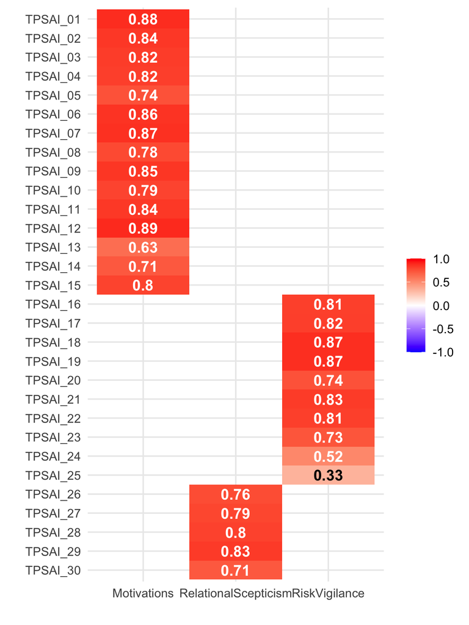

```r
plot_loadings(m3_loadings)
```

```r
lavaan::standardizedSolution(m3, type = "std.all") |>
  subset(op == "=~") |>
  pivot_wider(
    names_from = "lhs",
    values_from = "est.std",
    id_cols = "rhs"
  ) |> arrange(rhs) |> kable(digits = 2)
```

| rhs | Motivations | RelationalScepticism | RiskVigilance |
| --- | --- | --- | --- |
| TPSAI_01 | 0.88 | NA | NA |
| TPSAI_02 | 0.84 | NA | NA |
| TPSAI_03 | 0.82 | NA | NA |
| TPSAI_04 | 0.82 | NA | NA |
| TPSAI_05 | 0.74 | NA | NA |
| TPSAI_06 | 0.86 | NA | NA |
| TPSAI_07 | 0.87 | NA | NA |
| TPSAI_08 | 0.78 | NA | NA |
| TPSAI_09 | 0.85 | NA | NA |
| TPSAI_10 | 0.79 | NA | NA |
| TPSAI_11 | 0.84 | NA | NA |
| TPSAI_12 | 0.89 | NA | NA |
| TPSAI_13 | 0.63 | NA | NA |
| TPSAI_14 | 0.71 | NA | NA |
| TPSAI_15 | 0.80 | NA | NA |
| TPSAI_16 | NA | NA | 0.81 |
| TPSAI_17 | NA | NA | 0.82 |
| TPSAI_18 | NA | NA | 0.87 |
| TPSAI_19 | NA | NA | 0.87 |
| TPSAI_20 | NA | NA | 0.74 |
| TPSAI_21 | NA | NA | 0.83 |
| TPSAI_22 | NA | NA | 0.81 |
| TPSAI_23 | NA | NA | 0.73 |
| TPSAI_24 | NA | NA | 0.52 |
| TPSAI_25 | NA | NA | 0.33 |
| TPSAI_26 | NA | 0.76 | NA |
| TPSAI_27 | NA | 0.79 | NA |
| TPSAI_28 | NA | 0.80 | NA |
| TPSAI_29 | NA | 0.83 | NA |
| TPSAI_30 | NA | 0.71 | NA |

# Reliability

Reliability metrics evaluate the internal consistency of the latent factors based on the estimated CFA model parameters. We compute both Cronbach’s Alpha (α) and McDonald’s Omega (ω) for the selected models to assess how well each factor’s items measure the underlying construct. Generally, reliability coefficients of 0.70 or higher are considered acceptable for research purposes, with 0.80 or higher preferred for high-stakes applications. Conversely, coefficients above roughly 0.95 can indicate item redundancy rather than superior measurement, since near-paraphrased items inflate internal consistency while adding little construct coverage; we therefore read very high values as a signal to inspect item content rather than as evidence of quality.

```r
rel_m3 <- reliability(m3)
```

All coefficients are based on **ordinal indicators** (7-point Likert scale), so we report **α.ord** (Cronbach’s alpha using polychoric correlations) rather than the standard alpha which assumes continuous data.

```r
bind_rows(
  tibble(
    Factor = "Motivations",
    `α.ord` = round(rel_m3["alpha.ord", "Motivations"], 3),
    `ω` = round(rel_m3["omega", "Motivations"], 3)
  ),
  tibble(
    Factor = "Concerns",
    `α.ord` = round(rel_m3["alpha.ord", "RiskVigilance"], 3),
    `ω` = round(rel_m3["omega", "RiskVigilance"], 3)
  ),
  tibble(
    Factor = "RelationalScepticism",
    `α.ord` = round(rel_m3["alpha.ord", "RelationalScepticism"], 3),
    `ω` = round(rel_m3["omega", "RelationalScepticism"], 3)
  )
) |> kable(col.names = c("Factor", "α.ord", "ω"))
```

| Factor | α.ord | ω |
| --- | --- | --- |
| Motivations | 0.965 | 0.960 |
| Concerns | 0.924 | 0.912 |
| RelationalScepticism | 0.881 | 0.860 |

# Test-Retest Reliability

We compute test-retest reliability using a follow-up sample of N = 100 respondents who re-completed TPSai one week after the CFA.

```r
retest_file_path <- "data/shared/TPSai+-+Prolific_Retest.csv"
raw_retest_data  <- read_csv(retest_file_path, n_max = 2)
retest_colnames  <- names(raw_retest_data)
raw_retest_data  <- read_csv(retest_file_path, col_names = retest_colnames, skip = 2)
```

```r
cols_tpsai_retest_raw <- paste0(cols_tpsai_raw, "_t2")
cols_tpsai_retest <- paste0(cols_tpsai, "_t2")
trust_items_retest <- sprintf("TPSAI_%02d_t2", 1:15)
rv_items_retest <- sprintf("TPSAI_%02d_t2", 16:25)
rs_items_retest  <- sprintf("TPSAI_%02d_t2", 26:30)

retest_data <- raw_retest_data |>
  rename(all_of(setNames(cols_tpsai_raw, cols_tpsai))) |>
  rename(all_of(setNames(cols_tpsai_retest_raw, cols_tpsai_retest))) |>
  mutate(across(all_of(cols_tpsai), ~ likert_levels[.x])) |>
  mutate(across(all_of(cols_tpsai_retest), ~ likert_levels[.x])) |>
  mutate(
    motivations_score = rowMeans(across(all_of(trust_items))),
    concerns_score = rowMeans(across(all_of(rv_items))),
    rel_scept_score = rowMeans(across(all_of(rs_items))),
    motivations_score_t2 = rowMeans(across(all_of(trust_items_retest))),
    concerns_score_t2 = rowMeans(across(all_of(rv_items_retest))),
    rel_scept_score_t2 = rowMeans(across(all_of(rs_items_retest)))
  ) |>
  select(
    motivations_score, concerns_score, rel_scept_score,
    motivations_score_t2, concerns_score_t2, rel_scept_score_t2
  )
```

We evaluate test-retest reliability via:

- **Intraclass Correlation Coefficient (ICC)**, two-way random effects with one rating per subject: the proportion of score variance attributable to stable between-person differences rather than change or error (< .50 poor, .50–.75 moderate, .75–.90 good, > .90 excellent). We use absolute-agreement ICC rather than Pearson because Pearson is insensitive to systematic drift: if all scores shift in the same direction between occasions, Pearson remains high while ICC falls.
- **Standard Error of Measurement (SEM)** expresses measurement error in scale points, giving a confidence band around an individual score. An SE< of 0.35 on a 7-point scale means an observed score of 4.2 is 4.2 ± 0.69 at 95% confidence.
- **Reliable Change Index (RCI)**, the smallest change in an individual’s score distinguishable from measurement error.
- **ICC/ω**, the proportion of *reliable* variance that is stable across occasions. A score cannot be more stable than it is reliable, so raw ICCs are not comparable across subscales of differing reliability. ICC ≈ ω indicates that no systematic variance is changing; ICC ≪ ω indicates reliable variance that moves between occasions, which is the situational signal.

```r
omegas <- c(motivations_score = 0.96, concerns_score = 0.912, rel_scept_score = 0.859)

map_dfr(names(omegas), \(s) {
  x   <- retest_data[[s]]
  y   <- retest_data[[paste0(s, "_t2")]]
  icc <- psych::ICC(cbind(x, y))$results |> filter(type == "ICC2")
  sem <- sd(x) * sqrt(1 - icc$ICC)

  tibble(
    scale     = s,
    r         = cor(x, y),
    ICC       = icc$ICC,
    ci        = sprintf("[%.3f, %.3f]", icc$`lower bound`, icc$`upper bound`),
    icc_omega = icc$ICC / omegas[[s]],
    SEm       = sem,
    RCI       = 2.77 * sem
  )
}) |>
  kable(digits = 3,
        col.names = c("Scale", "r", "ICC(2,1)", "95% CI", "ICC/ω", "SE~m~", "RCI"))
```

| Scale | r | ICC(2,1) | 95% CI | ICC/ω | SE<sub>m</sub> | RCI |
| --- | --- | --- | --- | --- | --- | --- |
| motivations_score | 0.908 | 0.906 | [0.863, 0.935] | 0.943 | 0.418 | 1.158 |
| concerns_score | 0.816 | 0.817 | [0.741, 0.873] | 0.896 | 0.509 | 1.409 |
| rel_scept_score | 0.762 | 0.762 | [0.667, 0.833] | 0.887 | 0.566 | 1.568 |

The criteria pull against each other: a high ICC supports retest reliability but weakens the claim that TPSai is situational, since it indicates the score is largely a stable person characteristic. We interpret retest stability relative to the PTT-A short form (Scholz et al. 2025), which reports r~TT~ = .71 over approximately one year (ω = .83). Because our interval is one week, a comparable or lower TPSai value would indicate *less* stability than an explicitly dispositional measure, supporting the situational interpretation; a substantially higher value is expected on interval alone and is therefore not by itself evidence of trait-likeness. We compare the ratio of stability to internal consistency rather than the raw coefficient, and use the Pearson correlation for this comparison since the published value is a Pearson r.

# Unexplained Variance

For transparency in reporting, when fitting models is also interesting to ask what variance they do not capture. Since global indices can mask localised misfit, we can inspect the largest standardised residual correlations. While we do not plan to use the results of standardised residual correlations in any specific modelling decisions, we compute and report them to interpreter their relative fit.

```r
resid_cor <- residuals(m3, type = "cor")$cov
resid_cor[upper.tri(resid_cor, diag = TRUE)] <- NA

as.data.frame(as.table(resid_cor)) |>
  filter(!is.na(Freq)) |>
  arrange(desc(abs(Freq))) |>
  head(10) |>
  transmute(item_1 = Var1, item_2 = Var2, residual_r = round(Freq, 3)) |>
  kable()
```

| item_1 | item_2 | residual_r |
| --- | --- | --- |
| TPSAI_25 | TPSAI_10 | 0.202 |
| TPSAI_25 | TPSAI_11 | 0.190 |
| TPSAI_25 | TPSAI_05 | 0.180 |
| TPSAI_25 | TPSAI_04 | 0.172 |
| TPSAI_30 | TPSAI_13 | 0.167 |
| TPSAI_27 | TPSAI_14 | 0.163 |
| TPSAI_30 | TPSAI_02 | 0.156 |
| TPSAI_25 | TPSAI_02 | 0.155 |
| TPSAI_25 | TPSAI_15 | 0.139 |
| TPSAI_25 | TPSAI_22 | 0.139 |

## References

Boateng, Godfred O., Torsten B. Neilands, Edward A. Frongillo, Hugo R. Melgar-Quiñonez, and Sera L. Young. 2018. “Best Practices for Developing and Validating Scales for Health, Social, and Behavioral Research: A Primer.” *Frontiers in Public Health* 6 (June). https://doi.org/10.3389/fpubh.2018.00149.

Cheung, Gordon W., and Roger B. Rensvold. 2002. “Evaluating Goodness-of-Fit Indexes for Testing Measurement Invariance.” *Structural Equation Modeling: A Multidisciplinary Journal* 9 (2): 233–55. https://doi.org/10.1207/S15328007SEM0902_5.

Scholz, David D., Johannes Kraus, and Linda Miller. 2025. “Measuring the Propensity to Trust in Automated Technology: Examining Similarities to Dispositional Trust in Other Humans and Validation of the PTT-a Scale.” *International Journal of HumanComputer Interaction* 41 (2): 970–93. https://doi.org/10.1080/10447318.2024.2307691.